# Figures worth showing

## Why those two lines went

**`panel.grid.minor`** draws lines at values with no label, so nobody can read anything off them.

. . .

**`panel.grid.major.x`** draws vertical lines on a **categorical** axis. They line up with category names rather than numbers, so they measure nothing.

. . .

That is the test for any piece of the frame: **does the reader use it to read the data?** If not, `element_blank()` it.

## Moving the legend

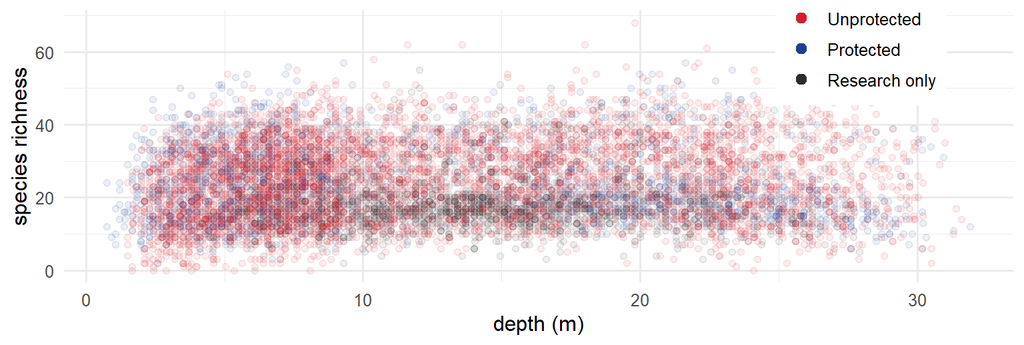

```r
ggplot(reef, aes(depth, richness, colour = protection_f)) +
  geom_point(alpha = 0.08) +
  scale_colour_manual(values = prime) +
  guides(colour = guide_legend(override.aes = list(alpha = 1, size = 2.5))) +
  theme_minimal(base_size = 12) +
  theme(legend.position        = "inside",
        legend.position.inside = c(0.84, 0.86),
        legend.background      = element_rect(fill = "white", colour = NA)) +
  labs(x = "depth (m)", y = "species richness", colour = NULL)
```

`override.aes` makes the legend keys solid even though the points are faint. `legend.position` also takes `"bottom"`, `"top"` and `"none"`.

## The gap between the bars and the axis

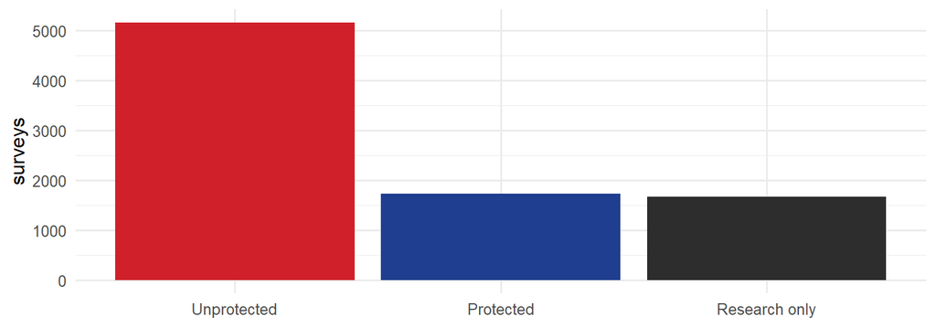

```r
bars <- ggplot(prot_counts, aes(protection, n, fill = protection)) +
  geom_col() +
  scale_fill_manual(values = prime, guide = "none") +
  theme_minimal(base_size = 12) +
  labs(x = NULL, y = "surveys")

bars
```

Look at the bottoms of the bars. They **float above the x axis** instead of sitting on it.

## Why the gap is there

ggplot2 pads every continuous scale by **5% of the data range at each end** before anything is drawn. You did not ask for it, and no argument in `geom_col()` controls it.

. . .

For points and lines that padding is right. A point at exactly the maximum would otherwise be drawn half outside the panel and get clipped.

. . .

For bars it is wrong, because a bar’s baseline is **a real value, zero**. Padding below zero puts blank space where the reader expects the axis, so the bars no longer touch the baseline they are measured from. It is a small thing, and it is what makes an otherwise fine bar chart look slightly off without anyone being able to say why.

## expand, and expansion()

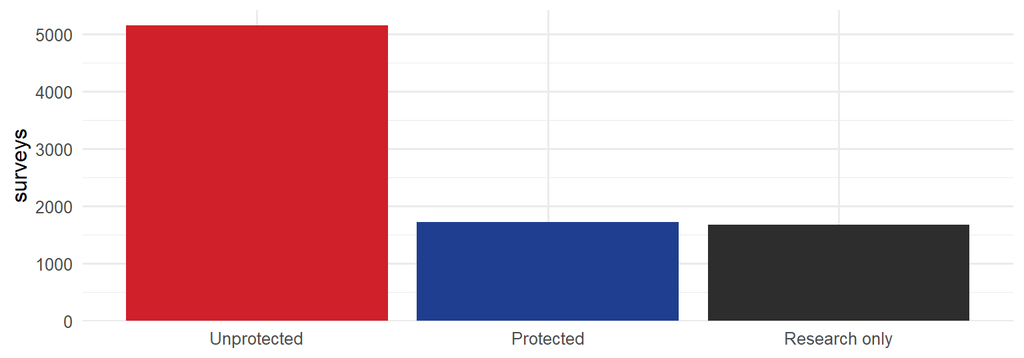

```r
bars + scale_y_continuous(expand = expansion(mult = c(0, 0.05)))
```

Nothing below, the usual 5% above: the bars sit on the axis, and the tallest still has headroom.

## How expansion() works

The padding lives on the **scale**, not the geom, which is why the fix is a `scale_y_continuous()` call. `expansion()` builds it out of two kinds:

- **`mult`**, a proportion of the data range
- **`add`**, in the units of the data

Each takes one number for both ends, or `c(lower, upper)`. So `expansion(mult = c(0, 0.05))` reads as **0% below, 5% above**.

. . .

The headroom matters more than it looks. Take it away too and the tallest bar runs into the top of the panel, which reads as a value that was cut off.

## Horizontal bars: fix x, not y

[figure not shown]

```r
ggplot(hab_counts, aes(x = n, y = reorder(habitat, n))) +
  geom_col(fill = "#3B6B8F") +
  scale_x_continuous(expand = expansion(mult = c(0, 0.05))) +
  theme_minimal(base_size = 8) +
  labs(x = "surveys", y = NULL)
```

Change the scale the bars **grow along**. The one they sit on is fine left alone.

## Flush is not always right

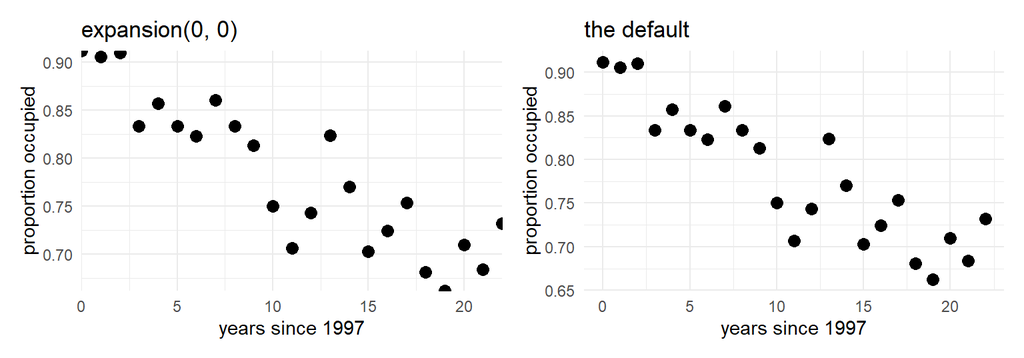

```r
occ_pts <- ggplot(occ, aes(elapsed, prop)) +
  geom_point(size = 3) +
  labs(x = "years since 1997", y = "proportion occupied")

(occ_pts + scale_x_continuous(expand = expansion(0, 0)) +
           scale_y_continuous(expand = expansion(0, 0)) +
           theme_minimal() + labs(title = "expansion(0, 0)")) |
  (occ_pts + theme_minimal() + labs(title = "the default"))
```

On the left, the first, last and lowest years are each cut in half by the border.

## The four cases you will need

**The rule:** drop the padding on the side where zero is a baseline the geom is drawn from. Keep it wherever the extreme value is a data point, as it is for the bobwhite years.

| What you want | Code |
| --- | --- |
| bars flush to the axis, headroom above | `expansion(mult = c(0, 0.05))` |
| flush at both ends: a filled area, a raster, a map | `expansion(0, 0)` |
| a fixed pad, in data units | `expansion(add = c(0, 2))` |
| the default back | leave `expand` out |

. . .

## ylim() is not expansion

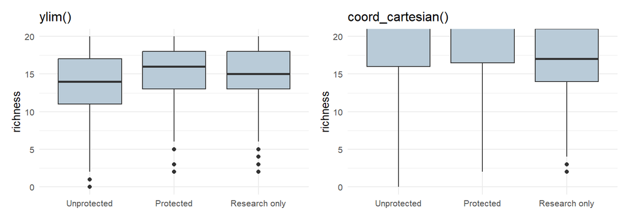

```r
box <- ggplot(reef, aes(protection_f, richness)) +
  geom_boxplot(fill = "#B9CBD8") +
  theme_minimal(base_size = 10) +
  labs(x = NULL, y = "richness")

(box + ylim(0, 20) + labs(title = "ylim()")) |
  (box + coord_cartesian(ylim = c(0, 20)) + labs(title = "coord_cartesian()"))
```

Same data, same y range, and two different sets of boxplots.

## What ylim() did

`ylim()`, and `scale_y_continuous(limits = )` with it, **throws away rows outside the range** before anything is computed.

. . .

Over half the surveys (4,662 of 8,560) have richness above 20, so the left boxplots are built from what is left, and the unprotected median falls from 24 to 14. ggplot2 mentions this only in a warning about “removed rows”, which is easy to scroll past.

. . .

**`coord_cartesian()` zooms** the finished figure and keeps all the data. That is almost always the one you meant.

. . .

**Expansion does neither.** It changes the padding only, never the limits and never the data.

## Putting it together

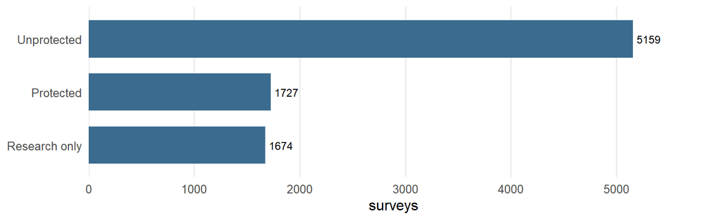

```r
ggplot(prot_counts, aes(n, reorder(protection, n))) +
  geom_col(fill = "#3B6B8F", width = 0.7) +
  geom_text(aes(label = n), hjust = -0.15, size = 3.2) +
  scale_x_continuous(expand = expansion(mult = c(0, 0.12))) +
  theme_minimal(base_size = 12) +
  theme(panel.grid.major.y = element_blank(),
        panel.grid.minor   = element_blank()) +
  labs(x = "surveys", y = NULL)
```

Flush bars, 12% headroom so the labels fit, and no grid lines that measure nothing.

# Taking it with you

## What this buys you

1. **Match the palette to the data.** Ordered data gets an ordered palette. This is the cheapest improvement available to you.
2. **Check for color blindness** with `deutan()` on your palette, or just look at the figure in greyscale, before anything goes in a talk.
3. **Show the shape** when the shape is the point: a violin for a few groups, ridgelines for many. A boxplot hides it.
4. **Make one point per figure**, and grey out everything that is not it.
5. **Reach for a bar chart** when slices need comparing. Pie or donut matters much less than people say.
6. **Plot your model over your data**, with a band. Grid, predict, plot.
7. **Choose the frame on purpose.** Pick a theme, set `base_size` for where the figure will be shown, and sit bars on their axis with `expansion(mult = c(0, 0.05))`.

## Where it fits

- **Assignments 3 and 4**: the model-prediction recipe in Part 5 applies directly to anything you fit
- **The final project presentation**: Parts 1, 3 and 4. A talk is where a cluttered figure costs you the most, because nobody can pause on it
- **Your own papers, later**: Part 5 and the color blindness check
- **Every figure you make**: Part 8. `theme_set()` at the top of a script is one line, and it makes every figure after it match

## Going further: learning

- **ggplot2 book**, free online: https://ggplot2-book.org
- **R Graph Gallery**, worked examples of nearly every chart type: https://r-graph-gallery.com
- **Fundamentals of Data Visualization**, Claus Wilke, free online and the best single source on *why* a figure works: https://clauswilke.com/dataviz
- **Data Visualization: A Practical Introduction**, Kieran Healy, free online, ggplot2 from the ground up: https://socviz.co
- **patchwork**: https://patchwork.data-imaginist.com
- **ggridges vignette**: `vignette("introduction", package = "ggridges")`

## Going further: the evidence

- **Franconeri et al. (2021)**, the review from Part 4, and the best place to start: https://doi.org/10.1177/15291006211051956
- **Cleveland and McGill (1984)**, the original ranking: https://doi.org/10.1080/01621459.1984.10478080
- **Heer and Bostock (2010)**, the replication: https://doi.org/10.1145/1753326.1753357
- **Saket et al. (2019)**, effectiveness by task: https://arxiv.org/abs/1709.08546
- **Skau and Kosara (2016)**, pies and donuts: https://doi.org/10.1111/cgf.12888
- **Crameri, Shephard and Heron (2020)**, on rainbow color maps and how color misleads, the reading for Part 1: https://doi.org/10.1038/s41467-020-19160-7

. . .

If you want a figure reviewed, bring it to office hours. That is a faster way to improve than reading any of the above.